# REPORTE 5

David Flores

2026-06-27

```r
reporte5<-table.b2
reporte5
```

```
##        y     x1    x2    x3    x4    x5
## 1  271.8 783.35 33.53 40.55 16.66 13.20
## 2  264.0 748.45 36.50 36.19 16.46 14.11
## 3  238.8 684.45 34.66 37.31 17.66 15.68
## 4  230.7 827.80 33.13 32.52 17.50 10.53
## 5  251.6 860.45 35.75 33.71 16.40 11.00
## 6  257.9 875.15 34.46 34.14 16.28 11.31
## 7  263.9 909.45 34.60 34.85 16.06 11.96
## 8  266.5 905.55 35.38 35.89 15.93 12.58
## 9  229.1 756.00 35.85 33.53 16.60 10.66
## 10 239.3 769.35 35.68 33.79 16.41 10.85
## 11 258.0 793.50 35.35 34.72 16.17 11.41
## 12 257.6 801.65 35.04 35.22 15.92 11.91
## 13 267.3 819.65 34.07 36.50 16.04 12.85
## 14 267.0 808.55 32.20 37.60 16.19 13.58
## 15 259.6 774.95 34.32 37.89 16.62 14.21
## 16 240.4 711.85 31.08 37.71 17.37 15.56
## 17 227.2 694.85 35.73 37.00 18.12 15.83
## 18 196.0 638.10 34.11 36.76 18.53 16.41
## 19 278.7 774.55 34.79 34.62 15.54 13.10
## 20 272.3 757.90 35.77 35.40 15.70 13.63
## 21 267.4 753.35 36.44 35.96 16.45 14.51
## 22 254.5 704.70 37.82 36.26 17.62 15.38
## 23 224.7 666.80 35.07 36.34 18.12 16.10
## 24 181.5 568.55 35.26 35.90 19.05 16.73
## 25 227.5 653.10 35.56 31.84 16.51 10.58
## 26 253.6 704.05 35.73 33.16 16.02 11.28
## 27 263.0 709.60 36.46 33.83 15.89 11.91
## 28 265.8 726.90 36.26 34.89 15.83 12.65
## 29 263.8 697.15 37.20 36.27 16.71 14.06
```

```r
str(reporte5)
```

```
## 'data.frame':    29 obs. of  6 variables:
##  $ y : num  272 264 239 231 252 ...
##  $ x1: num  783 748 684 828 860 ...
##  $ x2: num  33.5 36.5 34.7 33.1 35.8 ...
##  $ x3: num  40.5 36.2 37.3 32.5 33.7 ...
##  $ x4: num  16.7 16.5 17.7 17.5 16.4 ...
##  $ x5: num  13.2 14.1 15.7 10.5 11 ...
```

Esto nos permitirá visualizar la organización de la base de datos, observar la disposción de variables así como un bosquejo de la naturaleza de los mismos, es decir, determinar si hay NAs saber que variables son numéricas, etc.  
## Resumen numérico y gráfico

```
##        y    x1     x2    x3    x4     x5
## y   1.00  0.63  0.102  0.11 -0.85 -0.351
## x1  0.63  1.00 -0.204 -0.11 -0.63 -0.584
## x2  0.10 -0.20  1.000 -0.33 -0.12 -0.065
## x3  0.11 -0.11 -0.329  1.00  0.29  0.697
## x4 -0.85 -0.63 -0.117  0.29  1.00  0.685
## x5 -0.35 -0.58 -0.065  0.70  0.68  1.000
```

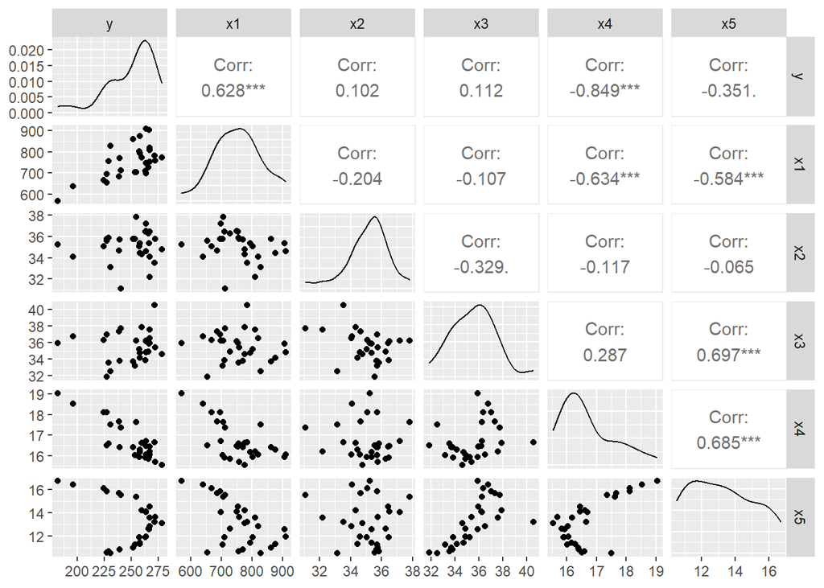

```
##
##  Pearson's product-moment correlation
##
## data:  reporte5$y and reporte5$x2
## t = 0.53464, df = 27, p-value = 0.5973
## alternative hypothesis: true correlation is not equal to 0
## 95 percent confidence interval:
##  -0.2744489  0.4519056
## sample estimates:
##       cor
## 0.1023521
```

Posteriormente se realizará un análisis de correlación entre variables generando una matriz de correlaciones que es el objeto **corres1** el cual se dicta la instrucción que nos de sus resultados solo con dos dígitos decimales.  
Con la función **ggpairs** nos otorga un gráfico que nos da los datos sobre las correlaciones así como la distribución gráfica de los datos para poder observar si existe alguna agrupación evidente o no así como determinar las significancias de cada una de las correlaciones.  
En este gráfico se observa que la variable x2 tiene un índice de correlación bajo con la variable de respuesta siendo 0.1, además se observa que las variables x3 y x4 tienen un alto índice de correlación con la variable x5 lo que puede indicar multicolinealidad.  
Para evitar este efecto y que cause confusión en nuestro modelo de regresión linear lo que se hará será eliminar la variable x5 del modelo y seguir. Para fines de este reporte se utilizarán ambos modelos, con y sin x5 para evaluar las diferencias entre ellos y si hay cambios en el ajuste y significancia del mismo.

## Modelo de regresión lineal

```r
MODELOLINEAR<-lm(y~x1+x2+x3+x4+x5,data=reporte5)
MODELOLINEARSINX5<-lm(y~x1+x2+x3+x4,data=reporte5)
summary(MODELOLINEAR)
```

```
##
## Call:
## lm(formula = y ~ x1 + x2 + x3 + x4 + x5, data = reporte5)
##
## Residuals:
##      Min       1Q   Median       3Q      Max
## -13.6848  -2.7688   0.6273   3.9166  17.3962
##
## Coefficients:
##              Estimate Std. Error t value Pr(>|t|)
## (Intercept) 325.43612   96.12721   3.385  0.00255 **
## x1            0.06753    0.02899   2.329  0.02900 *
## x2            2.55198    1.24824   2.044  0.05252 .
## x3            3.80019    1.46114   2.601  0.01598 *
## x4          -22.94947    2.70360  -8.488 1.53e-08 ***
## x5            2.41748    1.80829   1.337  0.19433
## ---
## Signif. codes:  0 '***' 0.001 '**' 0.01 '*' 0.05 '.' 0.1 ' ' 1
##
## Residual standard error: 8.039 on 23 degrees of freedom
## Multiple R-squared:  0.8988, Adjusted R-squared:  0.8768
## F-statistic: 40.84 on 5 and 23 DF,  p-value: 1.077e-10
```

```r
summary(MODELOLINEARSINX5)
```

```
##
## Call:
## lm(formula = y ~ x1 + x2 + x3 + x4, data = reporte5)
##
## Residuals:
##     Min      1Q  Median      3Q     Max
## -14.322  -2.639   0.025   4.786  16.003
##
## Coefficients:
##              Estimate Std. Error t value Pr(>|t|)
## (Intercept) 270.21013   88.21060   3.063  0.00534 **
## x1            0.05156    0.02685   1.920  0.06676 .
## x2            2.95141    1.23167   2.396  0.02471 *
## x3            5.33861    0.91506   5.834 5.13e-06 ***
## x4          -21.11940    2.36936  -8.914 4.42e-09 ***
## ---
## Signif. codes:  0 '***' 0.001 '**' 0.01 '*' 0.05 '.' 0.1 ' ' 1
##
## Residual standard error: 8.17 on 24 degrees of freedom
## Multiple R-squared:  0.8909, Adjusted R-squared:  0.8727
## F-statistic: 48.99 on 4 and 24 DF,  p-value: 3.327e-11
```

Lo que se realizó fue hacer 2 modelos, uno con la variable x5 y otro sin la variable, posteriormente se obtuvo el resumen de los mismos para probar la significancia así como el grado de ajuste del modelo, en ambos casos se obtuvo una R ajustada del 87% con cambios en los decimales, así como un valor de p menor a 0.05.  
Ahora se usará la función *vif* para determinar la multicolinealidad de las variables en cada modelo

```r
vif(MODELOLINEAR)
```

```
##       x1       x2       x3       x4       x5
## 2.319035 1.355448 3.175970 2.612066 5.370059
```

```r
vif(MODELOLINEARSINX5)
```

```
##       x1       x2       x3       x4
## 1.925791 1.277792 1.206057 1.942421
```